# Final Project

Will Mercer

April 6 2023

## Preliminaries

Load libraries.

```r
library(Stat2Data)
library(tidyverse)
library(broom)
library(janitor)
library(DAAG)
```

## Question X

Some questions may require code chunks. If there is a random process involved, be sure to set the seed in the same code chunk.

```r
data("SandwichAnts")
```

The data set I want to look at is sandwich ants. This data is from a study done by Dominic Kelly on ants and their fondness for different combinations of sandwich. This dataset has 48 observations on 5 variables:

```r
glimpse(SandwichAnts)
```

```
Rows: 48
Columns: 5
$ Trial   <int> 1, 2, 3, 4, 5, 6, 7, 8, 9, 10, 11, 12, 13, 14, 15, 16, 17, 18, 19, 20, 21, 22, 23, 24, 25, 26, 27, 28, 29, 30, 31, 32…
$ Bread   <fct> WholeWheat, MultiGrain, Rye, MultiGrain, WholeWheat, WholeWheat, White, MultiGrain, Rye, Rye, White, MultiGrain, Whit…
$ Filling <fct> HamPickles, PeanutButter, HamPickles, HamPickles, HamPickles, HamPickles, PeanutButter, HamPickles, HamPickles, Vegem…
$ Butter  <fct> no, yes, yes, yes, no, yes, yes, no, yes, no, yes, yes, no, no, yes, no, yes, yes, no, no, no, no, no, yes, no, no, y…
$ Ants    <int> 34, 47, 67, 63, 65, 58, 51, 59, 65, 18, 57, 76, 48, 31, 26, 21, 57, 28, 21, 54, 38, 19, 53, 60, 29, 48, 22, 36, 50, 4…
```

I want to know if the ant count can be predicted by a number of factors like number of trials, bread, filling, and butter. First, a glance at a scatterplot of data `Ants` as the numerical response variable, `Trial` as a numerical explanatory, and `Filling` as our categorical explanatory variables. $H_0: \beta_{1} = 0$

$H_A: \beta_{1} \neq 0$

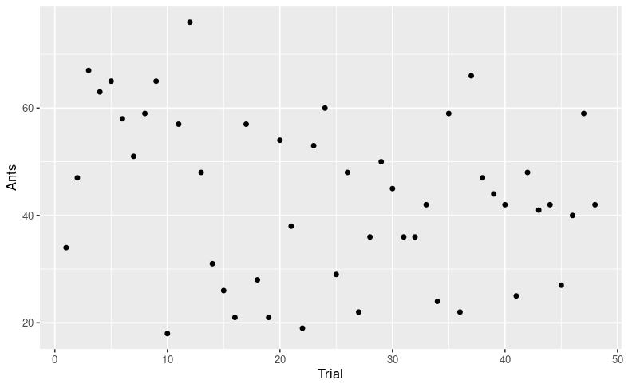

```r
ggplot(SandwichAnts, aes(y = Ants, x = Trial)) +
    geom_point()
```

Looks ok. Lets put a regression line on it:

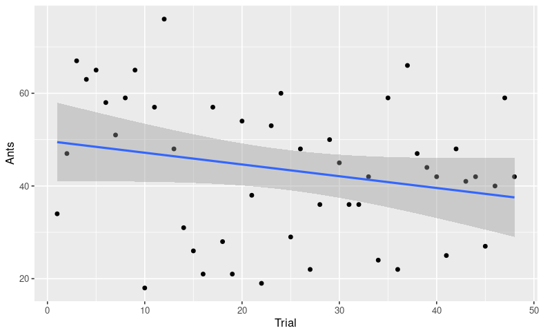

```r
ggplot(SandwichAnts, aes(y = Ants, x = Trial)) +
    geom_point() +
    geom_smooth(method = "lm")
```

Now running regression summaries:

```r
ants_lm <- lm(Ants ~ Trial + Filling, data = SandwichAnts)
ants_tidy <- tidy(ants_lm, conf.int = TRUE)
ants_tidy
```

| term | estimate | std.error | statistic | p.value | conf.low | conf.high |
| --- | --- | --- | --- | --- | --- | --- |
| (Intercept) | 57.03522028 | 4.0833746 | 13.9676680 | 0.000000000000000008854855 | 48.805720 | 65.2647210 |
| Trial | -0.08133617 | 0.1373108 | -0.5923507 | 0.556647781805280406075553 | -0.358068 | 0.1953956 |
| FillingPeanutButter | -14.46414359 | 4.5998171 | -3.1445041 | 0.002978718702653735967562 | -23.734466 | -5.1938213 |
| FillingVegemite | -20.16330848 | 4.6213819 | -4.3630474 | 0.000076394292516120105132 | -29.477092 | -10.8495252 |

```r
ants_aug <- augment(ants_lm, se_fit = TRUE)
ants_aug
```

| Ants | Trial | Filling | .fitted | .se.fit | .resid | .hat | .sigma | .cooksd | .std.resid |
| --- | --- | --- | --- | --- | --- | --- | --- | --- | --- |
| 34 | 1 | HamPickles | 56.95388 | 3.997631 | -22.953884 | 0.10031474 | 12.22271 | 0.1024696471 | -1.9173021 |
| 47 | 2 | PeanutButter | 42.40840 | 4.662696 | 4.591596 | 0.13646887 | 12.74544 | 0.0060548617 | 0.3914752 |
| 67 | 3 | HamPickles | 56.79121 | 3.835152 | 10.208788 | 0.09232610 | 12.66269 | 0.0183278923 | 0.8489633 |
| 63 | 4 | HamPickles | 56.70988 | 3.758806 | 6.290124 | 0.08868683 | 12.72809 | 0.0066304294 | 0.5220416 |
| 65 | 5 | HamPickles | 56.62854 | 3.685995 | 8.371461 | 0.08528426 | 12.69773 | 0.0112098142 | 0.6934862 |
| 58 | 6 | HamPickles | 56.54720 | 3.616934 | 1.452797 | 0.08211839 | 12.76560 | 0.0003228317 | 0.1201410 |
| 51 | 7 | PeanutButter | 42.00172 | 4.183124 | 8.998277 | 0.10984008 | 12.68458 | 0.0176133830 | 0.7556227 |
| 59 | 8 | HamPickles | 56.38453 | 3.490936 | 2.615469 | 0.07649676 | 12.76095 | 0.0009628635 | 0.2156304 |
| 65 | 9 | HamPickles | 56.30319 | 3.434444 | 8.696805 | 0.07404099 | 12.69308 | 0.0102496150 | 0.7160503 |
| 18 | 10 | Vegemite | 36.05855 | 3.976647 | -18.058550 | 0.09926438 | 12.43359 | 0.0626129052 | -1.5075228 |

[output cut: 38 more lines]

Checking for patterns in the residuals:

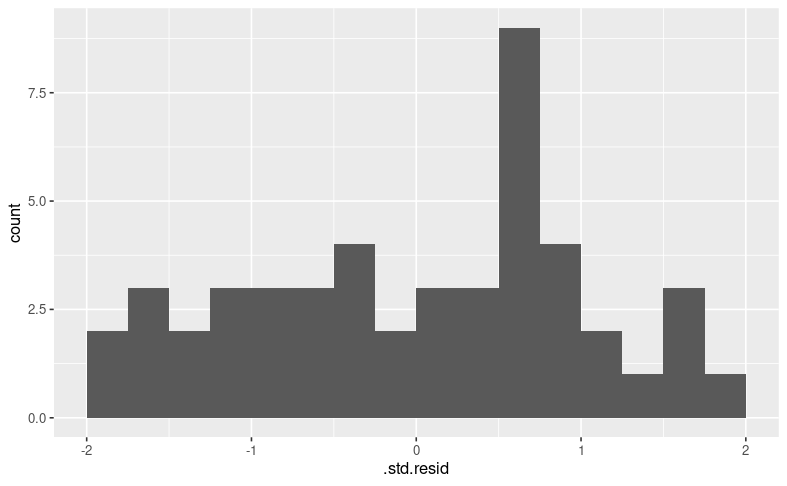

```r
ggplot(ants_aug, aes(x = .std.resid)) +
    geom_histogram(binwidth = 0.25, boundary = 0)
```

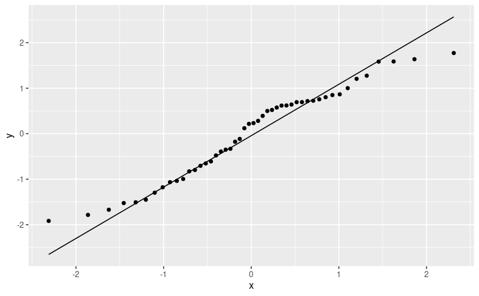

```r
ggplot(ants_aug, aes(sample = .std.resid)) +
    geom_qq() +
    geom_qq_line()
```

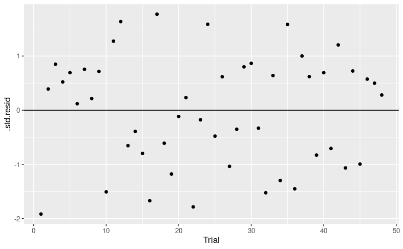

```r
ggplot(ants_aug, aes(y = .std.resid, x = Trial)) +
    geom_point() +
    geom_hline(yintercept = 0)
```

Very boring plot. That is a good thing.

Plotting standardized residuals of the model against fitted values:

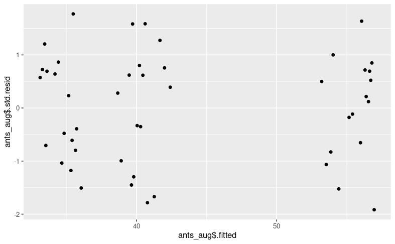

```r
ggplot(ants_aug, aes(y = ants_aug$.std.resid, x = ants_aug$.fitted)) +
    geom_point()
```

```r
ants_tidy
```

| term | estimate | std.error | statistic | p.value | conf.low | conf.high |
| --- | --- | --- | --- | --- | --- | --- |
| (Intercept) | 57.03522028 | 4.0833746 | 13.9676680 | 0.000000000000000008854855 | 48.805720 | 65.2647210 |
| Trial | -0.08133617 | 0.1373108 | -0.5923507 | 0.556647781805280406075553 | -0.358068 | 0.1953956 |
| FillingPeanutButter | -14.46414359 | 4.5998171 | -3.1445041 | 0.002978718702653735967562 | -23.734466 | -5.1938213 |
| FillingVegemite | -20.16330848 | 4.6213819 | -4.3630474 | 0.000076394292516120105132 | -29.477092 | -10.8495252 |

The intercept is 57.0352203 and the slope is -0.0813362 and -14.4641436, -20.1633085. Therefore, the equation of the regression line could be written

$$\widehat{Ants} = 57.035 - 0.0813Trial -
14.464PB - 20.163Vegemite$$
> The model predicts that for each successive trial, there will be an ant decrease of -0.0813362.

## Going to run an ANOVA on this data set now

data set is based on observational data. This limits our scope of inference since we can’t guarantee “randomness” and draw meaningful interpretations as a representative population. Nevertheless, here is our hypothesis:

$H_{0}:$ There is no difference in the amount of ants for the sandwich toppings, HamPickles, PeanutButter, or Vegemite. $H_{A}:$ There is a difference in the amount of ants for the sandwich toppings, HamPickles, PeanutButter, or Vegemite.

$$H_{0}: \mu_{HamPickles}=\mu_{PeanutButter}=\mu_{Vegemite}$$

```r
SandwichAnts %>%
  tabyl(Filling) %>%
  adorn_totals()
```

```
      Filling  n   percent
   HamPickles 16 0.3333333
 PeanutButter 16 0.3333333
     Vegemite 16 0.3333333
        Total 48 1.0000000
```

```r
combine_means_fillings <- SandwichAnts %>%
  group_by(Filling) %>%
  summarise(mean_combine = mean(Ants))
combine_means_fillings
```

| Filling | mean_combine |
| --- | --- |
| HamPickles | 55.500 |
| PeanutButter | 40.375 |
| Vegemite | 34.625 |

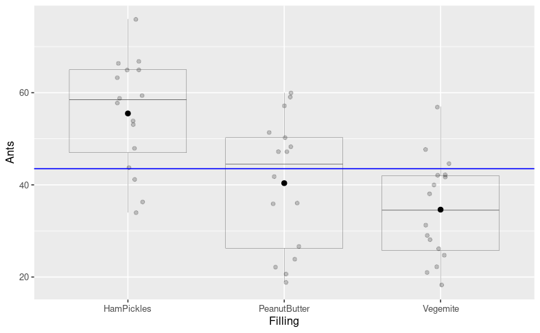

```r
ggplot(SandwichAnts, aes(y=Ants, x = Filling)) +
  geom_boxplot(lwd = 0.1, alpha = 0)+
  geom_jitter(width = 0.1, alpha = 0.2)+
  geom_point(data=combine_means_fillings, aes(y=mean_combine, x = Filling),
             size=2) +
  geom_hline(yintercept = sum(combine_means_fillings$mean_combine)/3, color = "blue")
```

Starting to see something going on with Ham & Pickles sandwiches.

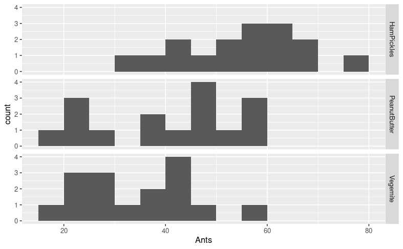

```r
ggplot(SandwichAnts, aes(x= Ants)) +
  geom_histogram(binwidth = 5, boundary = 0)+
  facet_grid(Filling ~ .)
```

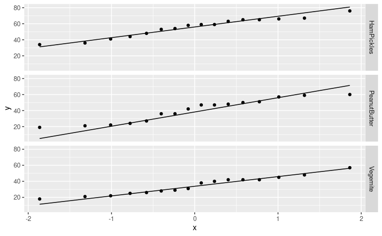

```r
ggplot(SandwichAnts, aes(sample = Ants))+
  geom_qq()+
  geom_qq_line()+
  facet_grid(Filling~.)
```

Now to run an ANOVA:

```r
str(SandwichAnts)
```

```
'data.frame':   48 obs. of  5 variables:
 $ Trial  : int  1 2 3 4 5 6 7 8 9 10 ...
 $ Bread  : Factor w/ 4 levels "MultiGrain","Rye",..: 4 1 2 1 4 4 3 1 2 2 ...
 $ Filling: Factor w/ 3 levels "HamPickles","PeanutButter",..: 1 2 1 1 1 1 2 1 1 3 ...
 $ Butter : Factor w/ 2 levels "no","yes": 1 2 2 2 1 2 2 1 2 1 ...
 $ Ants   : int  34 47 67 63 65 58 51 59 65 18 ...
```

```r
SA_test2 <- aov(Ants~ Filling, data = SandwichAnts)
SA_test2
```

```
Call:
   aov(formula = Ants ~ Filling, data = SandwichAnts)

Terms:
                Filling Residuals
Sum of Squares   3720.5    7065.5
Deg. of Freedom       2        45

Residual standard error: 12.53041
Estimated effects may be unbalanced
```

```r
SA_test_tidy2 <- tidy(SA_test2)
SA_test_tidy2
```

| term | df | sumsq | meansq | statistic | p.value |
| --- | --- | --- | --- | --- | --- |
| Filling | 2 | 3720.5 | 1860.2500 | 11.84789 | 0.00007351161 |
| Residuals | 45 | 7065.5 | 157.0111 | NA | NA |

```r
F2 <- SA_test_tidy2$statistic[1]
F2
```

```
[1] 11.84789
```

```r
P2 <- SA_test_tidy2$p.value[1]
P2
```

```
[1] 0.00007351161
```

Our test statistic is 11.8478876. Our p-value is 0.0000735.This means that if there were truly no difference in the number of ants for the various sandwich toppings then we would have a 0.0073512% chance of seeing data again that is at least as extreme as the data we saw.

```r
SA_aov <- aov(Ants~Filling,data = SandwichAnts)
tidy(SA_aov)
```

| term | df | sumsq | meansq | statistic | p.value |
| --- | --- | --- | --- | --- | --- |
| Filling | 2 | 3720.5 | 1860.2500 | 11.84789 | 0.00007351161 |
| Residuals | 45 | 7065.5 | 157.0111 | NA | NA |

```r
TukeyHSD(SA_aov)
```

```
  Tukey multiple comparisons of means
    95% family-wise confidence level

Fit: aov(formula = Ants ~ Filling, data = SandwichAnts)

$Filling
                           diff       lwr        upr     p adj
PeanutButter-HamPickles -15.125 -25.86202  -4.387985 0.0038299
Vegemite-HamPickles     -20.875 -31.61202 -10.137985 0.0000698
Vegemite-PeanutButter    -5.750 -16.48702   4.987015 0.4037366
```

When you are finished with the assignment, please follow the steps below:

1. From the “Run” menu, select “Restart R and Run All Chunks”.
2. Deal with any code errors that crop up. Repeat steps 1–2 until there are no more errors.
3. Spell check your document by clicking the icon with “ABC” and a check mark.
4. Hit the “Preview” button one last time to generate the final draft of the .nb.html file that you will turn in.
5. Proofread the HTML file carefully.
6. In the “Files” tab, select the file with extension .nb.html by checking the box next to it. Click the “More” menu and then “Export”. This will download a copy of the HTML file to your computer.
7. Submit your assignment in Canvas.